# Hands on MORE

Maider Aguerralde Martin & Ángeles Arzalluz

2025-01-20

MORE (Multi-Omics REgulation) is an R package which is designed to infer condition-specific multi-omic regulatory networks. Developed by the BiostatOmics Lab, it is publicly available on the [BiostatOmics GitHub repository](https://github.com/BiostatOmics/MORE/).

MORE uses either Multiple Linear Regression (MLR) or Partial Least Squares (PLS) to model the expression of the features of a target omic as a function of experimental variables (e.g., disease or treatment) and the target feature’s potential regulators. For MLR, it applies advanced variable selection techniques such as ElasticNet or Iterative Sparse Group Lasso, while for PLS, it uses Jack-Knife or Permutation techniques in combination with the Variable Importance in Projection (VIP) to identify the significant regulators of the target omic feature expression in the biological system under study. Additionally, MORE can incorporate prior regulatory knowledge and clinical data.

# Installation

Currently, the package can be directly installed from GitHub using the `devtools` R package by:

```r
install.packages("devtools")
devtools::install_github("BiostatOmics/MORE")
```

For a more comprehensive overview of MORE functionalities, refer to the User Guide available [here](https://github.com/BiostatOmics/MORE/blob/main/vignettes/UsersGuide.pdf).

For further information on the methodological details, please read the paper [paper](https://doi.org/10.1093/bib/bbaf270).

# Load MORE

```r
library(MORE)
```

# Data

In this tutorial, we will use the [STATegra](https://www.nature.com/articles/s41597-019-0202-7) dataset, available [HERE](https://github.com/BiostatOmics/STATegra_data). A reduced version of this data is included in MORE as example data.

The STATegra dataset contains time-series data for pre-B-cell differentiation in mice, including six time points (0h, 2h, 6h, 12h, 18h, 24h). A set of samples has been subjected to drug-controlled induction of the Ikaros transcription factor, while the Control cells have not and, therefore, will not differentiate into B-cells.

First, load the data as follows:

```r
load('DataSTATegra.RData')
```

DataSTATegra loads the following objects:

- `GeneExpressionDE`: RNA-seq data. Matrix with differentially expressed genes across conditions in rows and samples in columns.
- `data.omics`: List including each of the regulatory omics of the RNA-seq. Each omic is included in the list as a matrix with regulators in rows and samples in columns
- `associations`: List containing pairs of gene-regulator known to interact, based on the literature and/or databases.
- `edesign`: Matrix including the experimental design for each sample.

**Important:** MORE requires that the GeneExpression matrix and all matrices of the regulatory omics contain data from the same samples and in the same order. If sample labels differ, MORE will assume that samples are in the same order.

Below, we preview each object to demonstrate how to format input data for MORE.

## GeneExpressionDE

```r
head(GeneExpressionDE)
```

```
##                    Batch_1_Ctr_0H Batch_2_Ctr_0H Batch_4_Ctr_0H Batch_1_Ctr_2H
## ENSMUSG00000000028      13.812612       14.03159      13.901656      13.929891
## ENSMUSG00000000056      13.470168       13.29205      12.828267      12.623622
## ENSMUSG00000000078      10.682646       10.35727      10.501151      10.588055
## ENSMUSG00000000093       6.910878        6.69301       7.139726       8.094464
## ENSMUSG00000000131      14.241408       14.39647      14.345537      14.381840
## ENSMUSG00000000134      10.963512       10.94442      11.147515      10.809237
##                    Batch_3_Ctr_2H Batch_4_Ctr_2H Batch_1_Ctr_6H Batch_3_Ctr_6H
## ENSMUSG00000000028      13.876085      14.126789      14.171622      13.872382
## ENSMUSG00000000056      12.997942      12.535726      12.991138      13.113399
## ENSMUSG00000000078      10.451858      10.444312      11.008301      10.434204
## ENSMUSG00000000093       7.535058       8.683042       7.659847       7.736197
## ENSMUSG00000000131      14.401952      14.302514      14.607419      14.443613
## ENSMUSG00000000134      11.009085      10.662868      10.994689      10.936161
##                    Batch_4_Ctr_6H Batch_1_Ctr_12H Batch_3_Ctr_12H
## ENSMUSG00000000028      14.199299       13.947157       13.958910
## ENSMUSG00000000056      12.767678       12.910736       12.670369
## ENSMUSG00000000078       9.839811       10.432909       10.979929
## ENSMUSG00000000093       8.327506        7.206325        6.810825
## ENSMUSG00000000131      14.562286       14.428646       14.508502
## ENSMUSG00000000134      10.942475       10.929800       10.964434
##                    Batch_4_Ctr_12H Batch_1_Ctr_18H Batch_3_Ctr_18H
## ENSMUSG00000000028        14.16333       13.924163       13.771880
## ENSMUSG00000000056        12.51459       12.992014       12.812824
## ENSMUSG00000000078        10.16331       11.325414       11.212417
## ENSMUSG00000000093         7.58449        7.093517        7.248715
## ENSMUSG00000000131        14.40876       14.373203       14.255694
## ENSMUSG00000000134        10.77230       11.145207       11.125737
##                    Batch_4_Ctr_18H Batch_1_Ctr_24H Batch_3_Ctr_24H
## ENSMUSG00000000028       14.043439        14.08774       14.006538
## ENSMUSG00000000056       12.490432        13.02470       12.888504
## ENSMUSG00000000078       10.705251        11.40895       11.134874
## ENSMUSG00000000093        7.952783         7.83131        6.891414
## ENSMUSG00000000131       14.630406        14.48066       14.534599
## ENSMUSG00000000134       11.092071        11.09345       10.956520
##                    Batch_4_Ctr_24H Batch_1_Ik_0H Batch_2_Ik_0H Batch_4_Ik_0H
## ENSMUSG00000000028       14.356622     13.726267     13.509564     13.826921
## ENSMUSG00000000056       12.675347     13.519628     13.542471     13.013013
## ENSMUSG00000000078       10.708153     10.903395     10.832873     10.366378
## ENSMUSG00000000093        8.090818      5.909092      6.071665      5.430375
```

[output cut: 15 more lines]

```
## ENSMUSG00000000134     10.148949     10.572215      10.368850      10.558487
##                    Batch_4_Ik_12H Batch_1_Ik_18H Batch_3_Ik_18H Batch_4_Ik_18H
## ENSMUSG00000000028      14.463167      14.004855      13.876694      13.774570
## ENSMUSG00000000056      14.129953      14.610906      14.352236      14.475980
## ENSMUSG00000000078      11.906972      13.845399      13.399489      13.019943
## ENSMUSG00000000093       8.362416       9.354684       9.470364       9.433288
## ENSMUSG00000000131      14.240393      13.373764      13.490624      13.319716
## ENSMUSG00000000134      10.099720      10.690735      10.598448      10.583839
##                    Batch_1_Ik_24H Batch_3_Ik_24H Batch_4_Ik_24H
## ENSMUSG00000000028      13.122652       13.25478       13.04647
## ENSMUSG00000000056      14.536249       14.00465       14.59179
## ENSMUSG00000000078      14.069741       13.96808       13.37502
## ENSMUSG00000000093       9.908516       10.38476       10.00137
## ENSMUSG00000000131      13.402803       13.61354       13.50323
## ENSMUSG00000000134      10.640646       10.64785       10.87545
```

## data.omics

```r
names(data.omics)
```

```
## [1] "miRNA"  "DNase"  "Methyl" "TF"
```

```r
head(data.omics$TF)
```

```
##        Batch_1_Ctr_0H Batch_2_Ctr_0H Batch_4_Ctr_0H Batch_1_Ctr_2H
## Aebp2        12.22395      12.150306      12.466659       12.32961
## Arid5a       10.68807      10.828572      11.036984       10.25517
## Arnt         12.07138      12.097724      11.952975       11.78439
## Atf5         12.04640      12.100254      12.087156       11.90088
## Bach1        11.32697      11.078204      11.600732       11.52229
## Bach2        10.07644       9.815858       9.941229       10.16261
##        Batch_3_Ctr_2H Batch_4_Ctr_2H Batch_1_Ctr_6H Batch_3_Ctr_6H
## Aebp2        12.18033      11.748933       11.62626      11.913101
## Arid5a       10.85727      11.014147       10.47256      10.832606
## Arnt         12.04485      11.827481       12.24367      11.955008
## Atf5         12.40206      12.226461       12.45344      12.082367
## Bach1        11.23721      10.633061       10.18854      10.587953
## Bach2        10.23626       9.600647       10.24675       9.927626
##        Batch_4_Ctr_6H Batch_1_Ctr_12H Batch_3_Ctr_12H Batch_4_Ctr_12H
## Aebp2       11.474894       12.197574       12.158654       11.997173
## Arid5a      10.780678        9.999411       10.433560       10.624653
## Arnt        11.966136       12.068147       12.026589       11.801792
## Atf5        12.062650       11.907337       11.867332       11.724152
## Bach1        9.550716       11.361125       11.039858       10.609525
## Bach2        9.230377        9.876050        9.589832        9.144911
##        Batch_1_Ctr_18H Batch_3_Ctr_18H Batch_4_Ctr_18H Batch_1_Ctr_24H
## Aebp2         12.26723       12.339893       11.880226        11.98678
## Arid5a        10.51481       10.644654       10.634071        10.40924
## Arnt          11.92147       11.860101       11.999485        12.13341
## Atf5          12.07705       11.756788       11.864217        11.99863
## Bach1         11.22957       10.739600       10.071387        10.90447
## Bach2          9.66680        9.298879        8.968471         9.48345
##        Batch_3_Ctr_24H Batch_4_Ctr_24H Batch_1_Ik_0H Batch_2_Ik_0H
## Aebp2         12.05587       11.841033     12.352378     12.455321
## Arid5a        10.64878       10.753693      9.603272      9.808411
## Arnt          12.22315       12.141061     12.123337     11.951414
## Atf5          11.97060       12.196417     12.909114     12.766892
## Bach1         10.99755       10.828105     11.321055     11.151565
## Bach2          9.68492        9.555569     10.820495     10.482650
##        Batch_4_Ik_0H Batch_1_Ik_2H Batch_3_Ik_2H Batch_4_Ik_2H Batch_1_Ik_6H
## Aebp2      12.328838      12.23556      11.95043     11.588762      12.14369
## Arid5a      9.652845      10.00335      10.07917     10.303031      11.27551
## Arnt       11.958987      12.02087      12.18980     11.943750      12.33023
## Atf5       13.082555      12.51929      12.67281     12.631968      12.41318
```

[output cut: 8 more lines]

```
## Bach2       11.04502      10.77882       12.32284       12.32997       11.50258
##        Batch_1_Ik_18H Batch_3_Ik_18H Batch_4_Ik_18H Batch_1_Ik_24H
## Aebp2        11.20803       11.58647       11.49201       11.12529
## Arid5a       12.53983       12.47864       12.81695       13.35515
## Arnt         12.78909       12.46749       12.56556       12.91835
## Atf5         12.24072       12.09649       11.94443       11.79752
## Bach1        12.58097       12.39286       12.49233       12.87248
## Bach2        14.61000       14.55518       14.65811       15.17393
##        Batch_3_Ik_24H Batch_4_Ik_24H
## Aebp2        10.96214       11.39214
## Arid5a       13.06921       13.25450
## Arnt         12.66581       12.84462
## Atf5         11.49572       11.50594
## Bach1        12.41205       12.53768
## Bach2        14.97761       14.92246
```

## associations

```r
names(associations)
```

```
## [1] "miRNA"  "DNase"  "Methyl" "TF"
```

```r
head(associations$TF)
```

```
##                 Gene Binder     Area
## 1 ENSMUSG00000000711  Aebp2 promoter
## 2 ENSMUSG00000001157  Aebp2 promoter
## 3 ENSMUSG00000001211  Aebp2 promoter
## 4 ENSMUSG00000001227  Aebp2 promoter
## 5 ENSMUSG00000001305  Aebp2 promoter
## 6 ENSMUSG00000001794  Aebp2 promoter
```

## edesign

```r
head(edesign)
```

```
##          Time Ikaros
## C0H_rep1    0      0
## C0H_rep2    0      0
## C0H_rep3    0      0
## C2H_rep1    2      0
## C2H_rep2    2      0
## C2H_rep3    2      0
```

# Running MORE

To run MORE, for any of its possible model types, we use the function `more()`. The user can specify the type of regression model (one of MLR, PLS1, or PLS2) with the parameter `method` and the variable selection method to apply with the `varSel` parameter (EN or ISGL for MLR, or Jack or Perm for PLS1 or PLS2).

However, some parameters are common for any regression or variable selection technique used:

- `omicType`: A vector with as many elements as the number of omics, indicating whether each omic contains numeric (0) or binary (1) values. If not specified, MORE will automatically detect the omic types. However, the user MUST stop the process if the automatic detection is incorrect.
- `minVariation`: A vector specifying the minimum required variation across conditions for a regulator to be included in the model.
- `scaleType`: Indicates the type of scaling to be used (one of auto, softBlock or hardBlock).
- `interactions`: By default, it is set to TRUE to allow MORE to test condition-dependent regulatory interactions. This effectively increases the number of predictors in the model but provides condition-specific regulators.
- `parallel`: By default, FALSE. Considers parallelization in numberOfCores-1 when TRUE or the number of cores the user asks for when a number is provided.

**Note:** MLR and PLS1 models create a model for each of the target omic features provided. PLS2 creates a unique model for all the target omic features, but cannot consider prior regulatory knowledge.

In this tutorial, the data we will use has already been partially preprocessed. We will apply low variation filtering thresholds to those regulatory omics that were not/barely filtered and set the threshold to 0 for those that were already filtered.

```r
## omic order: "miRNA"  "DNase"  "Methyl" "TF"
minVar = c(0, 0.1, 0.1, 0)
names(minVar) = names(data.omics)
```

MORE requires a single covariate representing sample conditions. In this dataset, we have information about the time and type of treatment, but we will only create MORE models to compare Ikaros vs control samples.

```r
edesign = edesign[,-1, drop=FALSE]
```

## MLR + EN

This is how an MLR model with ElasticNet variable selection would be run:

```r
MLRmodel = more(targetData = GeneExpressionDE,
                regulatoryData = data.omics,
                associations = associations,
                condition = edesign,
                omicType = 0,
                scaleType = 'auto',
                interactions = TRUE,
                minVariation = minVar,
                varSel = 'EN',
                alfaEN = NULL,
                correlation = 0.7,
                method = 'MLR',
                parallel = FALSE)
```

### Results

`MLRmodel` output is a list containing the following objects:

```r
names(MLRmodel)
```

```
## [1] "ResultsPerTargetF" "GlobalSummary"     "arguments"
```

#### ResultsPerTargetF

The list `ResultsPerTargetF` contains one element per target feature (genes in this example). For example, we show the information MORE returns for the gene *ENSMUSG00000000078*:

- `Y`: A data.frame with observed, fitted, and residual values for the target gene.
- `X`: A data.frame containing the predictor variables included in the model.
- `coefficients`: A matrix with the estimated coefficients for the selected regulators. The sign and magnitude of the coefficients indicate the direction and the strength of each association.
- `allRegulators`: A data.frame with all the potential regulators in rows and the following information in the columns: gene, regulator, omic, area (the third optional column in the associations table), filter (whether the regulator has been filtered out of the model, and the reason) and Rel (1 if the model has selected the regulator or 0 if not).
- `relevantRegulators`: A character vector containing the IDs of the relevant regulators selected by the model. If a “representative” of multicollinear regulators (mc) is detected as relevant, all the correlated regulators are also retrieved.

##### Y

```r
head(MLRmodel$ResultsPerTargetF$ENSMUSG00000000078$Y)
```

```
##                       y fitted.y   residuals
## Batch_1_Ctr_0H 10.68265 10.95963 -0.27698016
## Batch_2_Ctr_0H 10.35727 10.75850 -0.40122960
## Batch_4_Ctr_0H 10.50115 10.92592 -0.42476719
## Batch_1_Ctr_2H 10.58805 10.78495 -0.19689285
## Batch_3_Ctr_2H 10.45186 10.82678 -0.37492555
## Batch_4_Ctr_2H 10.44431 10.46397 -0.01965518
```

##### X

```r
head(MLRmodel$ResultsPerTargetF$ENSMUSG00000000078$X)
```

```
##                   Group_1 mmu-miR-674-3p miRNA_mc1_2_R Group_1:mmu-miR-674-3p
## Batch_1_Ctr_0H -0.9860133     -0.3923349    0.76659708             -0.9850282
## Batch_2_Ctr_0H -0.9860133      0.2057656    0.64057851             -0.9850282
## Batch_4_Ctr_0H -0.9860133     -0.8652439    1.86945791             -0.9850282
## Batch_1_Ctr_2H -0.9860133     -0.1425743   -0.03576606             -0.9850282
## Batch_3_Ctr_2H -0.9860133     -0.1880423    2.14397209             -0.9850282
## Batch_4_Ctr_2H -0.9860133     -0.8675292    1.14461195             -0.9850282
##                Group_1:miRNA_mc1_2_R       Cux1        Rfx1       Rfx7
## Batch_1_Ctr_0H            -0.9367131  0.3089238 -0.12916501 -0.1643226
## Batch_2_Ctr_0H            -0.9367131 -0.1162172  0.69960434  0.1824486
## Batch_4_Ctr_0H            -0.9367131  0.8230729 -0.51734142 -0.4196543
## Batch_1_Ctr_2H            -0.9367131  0.4530688 -1.12068461 -0.6584232
## Batch_3_Ctr_2H            -0.9367131  0.4225814 -0.56504351 -0.2870915
## Batch_4_Ctr_2H            -0.9367131 -0.4789062 -0.07989657 -1.7610519
##                       Tbp TF_mc1_1_R TF_mc1_3_R Group_1:Cux1 Group_1:Rfx1
## Batch_1_Ctr_0H 0.42898752 -0.4251771  0.8073937   -0.9855002   -0.9858849
## Batch_2_Ctr_0H 1.23428189 -0.5937534  0.3295782   -0.9855002   -0.9858849
## Batch_4_Ctr_0H 0.46710676 -0.4023151  1.3086554   -0.9855002   -0.9858849
## Batch_1_Ctr_2H 0.01575176 -0.6203624  0.9838123   -0.9855002   -0.9858849
## Batch_3_Ctr_2H 0.49663959 -0.5523413  0.6948895   -0.9855002   -0.9858849
## Batch_4_Ctr_2H 0.52086270 -0.6745922 -0.7478315   -0.9855002   -0.9858849
##                Group_1:Rfx7 Group_1:Tbp Group_1:TF_mc1_1_R Group_1:TF_mc1_3_R
## Batch_1_Ctr_0H   -0.9857311  -0.9856534         -0.9834218         -0.9832891
## Batch_2_Ctr_0H   -0.9857311  -0.9856534         -0.9834218         -0.9832891
## Batch_4_Ctr_0H   -0.9857311  -0.9856534         -0.9834218         -0.9832891
## Batch_1_Ctr_2H   -0.9857311  -0.9856534         -0.9834218         -0.9832891
## Batch_3_Ctr_2H   -0.9857311  -0.9856534         -0.9834218         -0.9832891
## Batch_4_Ctr_2H   -0.9857311  -0.9856534         -0.9834218         -0.9832891
```

##### coefficients

```r
head(MLRmodel$ResultsPerTargetF$ENSMUSG00000000078$coefficients)
```

```
##             coefficient
## (Intercept)  11.3927379
## Rfx7          0.1782640
## Tbp          -0.1618924
## TF_mc1_1_R    0.7864225
```

##### allRegulators

```r
head(MLRmodel$ResultsPerTargetF$ENSMUSG00000000078$allRegulators)
```

```
##                            targetF       regulator  omic area        filter Rel
## mmu-miR-381-3p  ENSMUSG00000000078  mmu-miR-381-3p miRNA      miRNA_mc1_2_P   0
## mmu-miR-410-3p  ENSMUSG00000000078  mmu-miR-410-3p miRNA      miRNA_mc1_2_R   0
## mmu-miR-674-3p  ENSMUSG00000000078  mmu-miR-674-3p miRNA              Model   0
## mmu-miR-466d-5p ENSMUSG00000000078 mmu-miR-466d-5p miRNA         TF_mc1_1_N   1
## mmu-miR-1187    ENSMUSG00000000078    mmu-miR-1187 miRNA         TF_mc1_1_N   1
## mmu-miR-669f-3p ENSMUSG00000000078 mmu-miR-669f-3p miRNA         TF_mc1_1_N   1
```

Note that some regulator include `_mc1_` followed by a number and letters `R`, `N` and `P` appended to their IDs (e.g. `mc1_1_P`). These suffixes indicate relationships within highly correlated subgroups of regulators. More specifically, the first number indicates the subgroup of highly connected regulators in the correlation network; for example, there may be two clusters of similarly correlated regulators, each of which has included a representative in the model: `mc1_1` and `mc1_2`. The suffix `_R` means that this regulator was selected as the representative for its group, while `_N` and `_P` mean that the regulator is negatively or positively correlated with its representative, respectively.

##### relevantRegulators

```r
head(MLRmodel$ResultsPerTargetF$ENSMUSG00000000078$relevantRegulators)
```

```
## [1] "Rfx7"            "Tbp"             "mmu-miR-466d-5p" "mmu-miR-1187"
## [5] "mmu-miR-669f-3p" "mmu-miR-466k"
```

#### GlobalSummary

The list `GlobalSummary` contains the general results of all the models created. We show the information MORE returns:

- `TargetFNOregu`: A matrix containing information about the genes with no initial regulators.
- `TargetFNOmodel`: A matrix containing information about the genes for which MLR models could not be fitted and the reason why (either an error during MLR fit or a lack of regulators remaining after elastic net variable selection).
- `GoodnessOfFit`: A matrix that collects the R-squared value, the Root Mean Squared Error (RMSE), the Normalized RMSE (NRMSE), and the number of relevant regulators selected by the model. The NRMSE is calculated by normalizing the RMSE using the range of the response variable ($y_{max} - y_{min}$). This information could help filter results, for instance, by selecting the regulatory models that best explain the gene variance across the conditions.
- `ReguPerTargetF`: A matrix containing, for each omic and gene, the number of initial regulators supplied (-Ini), the number of regulators included in the initial model (-Mod) after the series of filters applied by MORE, and the number of relevant regulators included in the final model (-Rel).
- `GlobalRegulators`: A vector of the most relevant regulators, i.e., those relevant for a larger part of the genes. It selects the third quartile of the regulators after ranking them by the number of regulations they have.
- `HubTargetF`: A vector of genes that accumulate a high number of regulators, according to the MORE models. The third quartile of the gene list ranked by the number of regulators (similar calculation to the one done for GlobalRegulators).

##### TargetFNOregu

```r
head(MLRmodel$GlobalSummary$TargetFNOregu)
```

```
##              targetF                                  problem
## 1 ENSMUSG00000000308 Target feature had no initial regulators
## 2 ENSMUSG00000002100 Target feature had no initial regulators
## 3 ENSMUSG00000002500 Target feature had no initial regulators
## 4 ENSMUSG00000019989 Target feature had no initial regulators
## 5 ENSMUSG00000021640 Target feature had no initial regulators
## 6 ENSMUSG00000023348 Target feature had no initial regulators
```

##### TargetFNOmodel

```r
head(MLRmodel$GlobalSummary$TargetFNOmodel)
```

```
##              targetF                                         problem
## 1 ENSMUSG00000005611 No relevant regulators after variable selection
## 2 ENSMUSG00000019935 No relevant regulators after variable selection
## 3 ENSMUSG00000021356 No relevant regulators after variable selection
## 4 ENSMUSG00000023232 No relevant regulators after variable selection
## 5 ENSMUSG00000024866 No relevant regulators after variable selection
## 6 ENSMUSG00000026712 No relevant regulators after variable selection
```

##### GoodnessOfFit

```r
head(MLRmodel$GlobalSummary$GoodnessOfFit)
```

```
##                    Rsquared     RMSE    NRMSE relReg
## ENSMUSG00000000028 0.846078 0.119685 0.084482     71
## ENSMUSG00000000056 0.943605 0.156327 0.073723     71
## ENSMUSG00000000078 0.888064 0.395218 0.093434     25
## ENSMUSG00000000093 0.527850 0.793015 0.160063      1
## ENSMUSG00000000131 0.833332 0.150970 0.110247     20
## ENSMUSG00000000134 0.772240 0.135788 0.121157     18
```

##### ReguPerTargetF

```r
head(MLRmodel$GlobalSummary$ReguPerTargetF)
```

```
##                    miRNA-Ini DNase-Ini Methyl-Ini TF-Ini miRNA-Mod DNase-Mod
## ENSMUSG00000000028         1         0          0     70         1         0
## ENSMUSG00000000056         6         0          0     65         6         0
## ENSMUSG00000000078         9         0          0     30         9         0
## ENSMUSG00000000093         0         0          0      1         0         0
## ENSMUSG00000000131         1         2          0     35         1         2
## ENSMUSG00000000134         2         0          0     30         2         0
##                    Methyl-Mod TF-Mod miRNA-Rel DNase-Rel Methyl-Rel TF-Rel
## ENSMUSG00000000028          0     70         1         0          0     70
## ENSMUSG00000000056          0     65         6         0          0     65
## ENSMUSG00000000078          0     30         6         0          0     19
## ENSMUSG00000000093          0      1         0         0          0      1
## ENSMUSG00000000131          0     35         0         0          0     20
## ENSMUSG00000000134          0     30         2         0          0     16
```

##### GlobalRegulators

```r
head(MLRmodel$GlobalSummary$GlobalRegulators)
```

```
## [1] "Aebp2"  "Arid5a" "Arnt"   "Atf5"   "Bach1"  "Bach2"
```

##### HubTargetF

```r
head(MLRmodel$GlobalSummary$HubTargetF)
```

```
## [1] "ENSMUSG00000000028" "ENSMUSG00000000056" "ENSMUSG00000000149"
## [4] "ENSMUSG00000000194" "ENSMUSG00000000278" "ENSMUSG00000000295"
```

## MLR + ISGL

To run MORE with Iterative Sparse Group Lasso variable selection, we would run:

```r
MLRISGLmodel = more(targetData = GeneExpressionDE,
                regulatoryData = data.omics,
                associations = associations,
                condition = edesign,
                omicType = 0,
                scaleType = 'auto',
                interactions = TRUE,
                minVariation = minVar,
                varSel = 'ISGL',
                groupingISGL = 'MF_0.7',
                method = 'MLR')
```

As shown, we slightly changed the main function’s parameters. In this case, we used `groupingISGL` instead of `alfaEN` to change from the EN alfa mixing parameter to the type of approach to consider when creating the groups in the ISGL. In this example, we used the multicollinearity approach (MF) with a correlation threshold of 0.7 to make the groups. Other options:

- `MF_X`: Takes the same approach as in the multicollinearity filter. Grouping the variables which correlate more than X.
- `PCA_X`: Extracts as many PCA components to explain X percent of the variability of the data and assigns the variables to the component in which they had the highest loadings.

## PLS1 + Jack + VIP

To run MORE with Partial Least Squares (PLS), we slightly change the parameters of the main function. In this case, we use `alfa` instead of `alfaEN` to change from EN alfa mixing parameter to alpha (I type error) threshold to consider a p-value significant.

In the case of PLS models, we will refer to significant regulators rather than relevant regulators. So outputs like `ResultsPerTargetF$relevantRegulators` change to outputs like `ResultsPerTargetF$significantRegulators`.

To run a PLS model with Jack-Knife as variable selection technique, we can run:

```r
PLSJackmodel = more(targetData = GeneExpressionDE,
                regulatoryData = data.omics,
                associations = associations,
                condition = edesign,
                omicType = 0,
                scaleType = 'auto',
                interactions = TRUE,
                minVariation = minVar,
                varSel = 'Jack',
                alfa = 0.05,
                method = 'PLS1')
```

## PLS1 + Perm + VIP

To run a PLS model with Permutation as variable selection technique, we can run:

```r
PLS1model = more(targetData = GeneExpressionDE,
                regulatoryData = data.omics,
                associations = associations,
                condition = edesign,
                omicType = 0,
                scaleType = 'auto',
                interactions = TRUE,
                minVariation = minVar,
                varSel = 'Perm',
                alfa = 0.05,
                method = 'PLS1')
```

## PLS2

All the above-presented models compute a unique model for each gene considered. However, when there is no prior regulatory knowledge, it could be beneficial to run a PLS2, which creates a unique model for all the genes. To do so, we run:

```r
PLS2mmodel = more(targetData = GeneExpressionDE,
                regulatoryData = data.omics,
                condition = edesign,
                omicType = 0,
                scaleType = 'auto',
                interactions = TRUE,
                minVariation = minVar,
                varSel = 'Perm',
                alfa = 0.05,
                method = 'PLS2')
```

# Interpreting MORE results

We will use the results from the PLS model with Jack-Knife variable selection to demonstrate the various functionalities that MORE incorporates.

First, we run the `RegulationPerCondition()` function, which returns a summary of the significant regulations for each gene. We can load the pre-computed results to avoid excessive runtime:

```r
regpcond = RegulationPerCondition(PLSJackmodel)
```

```r
load('RegulationperConditionPLS.RData')
```

```r
head(regpcond)
```

```
##              targetF regulator omic     area Group_0 Group_1
## 1 ENSMUSG00000000028      Cux1   TF promoter  0.3306  0.3306
## 2 ENSMUSG00000000028      E2f2   TF promoter  0.5325  0.5325
## 3 ENSMUSG00000000028      Elk4   TF promoter -0.5081 -0.5081
## 4 ENSMUSG00000000028      Fli1   TF promoter -0.1625 -0.1625
## 5 ENSMUSG00000000028     Foxm1   TF promoter  0.7202  0.7202
## 6 ENSMUSG00000000028     Foxo1   TF   public -0.1749 -0.1749
```

Looking at the results of `regpcond`, remember that `Group_0` and `Group_1` correspond to the Control and Ikaros conditions, respectively (as codified in `edesign`). The condition-specific coefficients can be interpreted as follows:

- If two experimental groups have the same coefficients, the regulator has the same effect on the gene in both conditions.
- If the coefficient is 0 in one of the groups, the regulator has no effect on the gene under that condition.
- Experimental conditions with different, non-zero coefficients indicate that the regulator affects the gene in these conditions, but the magnitude of the effect is not the same for the groups.

```r
regpcondMLR = RegulationPerCondition(MLRmodel)
```

We will also show the output of running the same function to the output of an MLR model with ElasticNet variable selection so that the user can see how information about multicollinearity is added to this output.

```r
head(regpcondMLR)
```

```
##              targetF      regulator  omic     area representative  Group_0
## 1 ENSMUSG00000000028           Atf5    TF promoter                 0.30780
## 2 ENSMUSG00000000028          Foxm1    TF promoter                 0.39160
## 3 ENSMUSG00000000028           Klf2    TF promoter                 0.06762
## 4 ENSMUSG00000000028         Zfp629    TF promoter                -0.36240
## 5 ENSMUSG00000000028         Zfp787    TF promoter                 0.00000
## 6 ENSMUSG00000000028 mmu-miR-342-3p miRNA                   Bach2 -0.07001
##    Group_1
## 1  0.23550
## 2  0.33150
## 3  0.06762
## 4 -0.46210
## 5 -0.10170
## 6 -0.16520
```

To further explore the results of MORE, we can start with some summary plots of the computed models.

The `summaryPlot` function represents the percentage of genes with relevant regulations and the percentage of regulations found to be relevant in each omic, depending on whether the `bytargetF` parameter is set to TRUE or FALSE. We can also stratify the results by filtering by $R^2$, e.g. see the percentage of genes for which the model explains at least 90% of the variance:

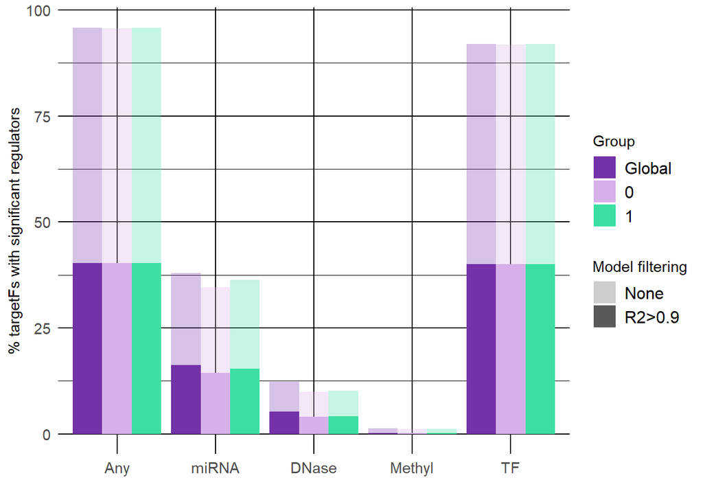

```r
summaryPlot(PLSJackmodel, regpcond, filterR2 = 0.9)
```

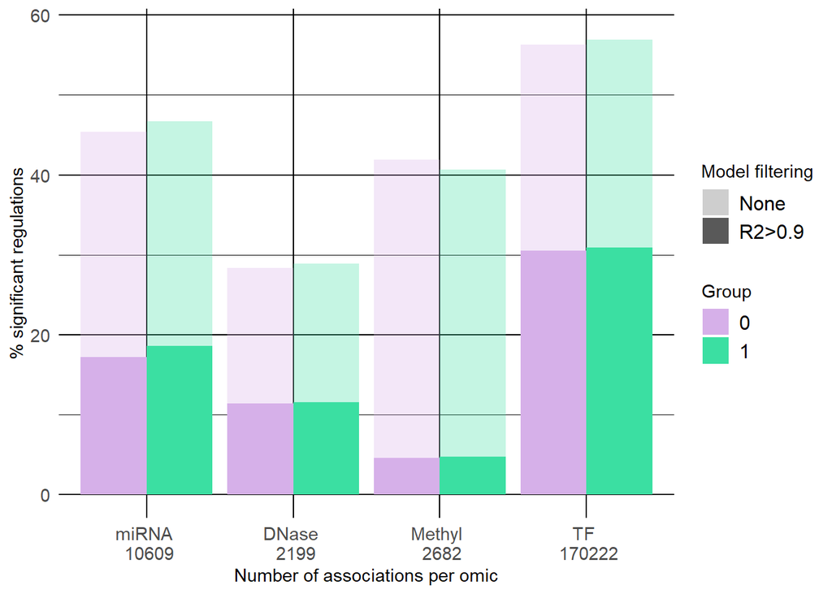

```r
summaryPlot(PLSJackmodel, regpcond, byTargetF = FALSE, filterR2 = 0.9)
```

After this prior study, if one is interested in focusing their efforts on analyzing the regulatory networks of a subset of genes that were better modelled by MORE, they can use `filterR2` to do so.

To create smaller regulatory networks, we will apply the filter previously used in this example ($R^2>0.9$).

In MORE, there are two ways to obtain the subset of genes that showed an $R^2$ above the one the user wants to consider. The first is:

```r
regpcond_filtered = RegulationPerCondition(MLRmodel, filterR2 = 0.9)
```

However, in the cases where MORE found a high amount of significant regulations this can be very time-consuming. So we recommend using this second option specially designed to apply the filter:

```r
regpcond_filtered = FilterRegulationPerCondition(output = PLSJackmodel, outputRegpcond = regpcond, filterR2 = 0.9)
```

To explore the differential regulators across experimental conditions and omics, MORE incorporates the `differentialRegPlot()` function. It can be applied either to the full set of genes or to those filtered by the $R^2$. In our case, we will apply it to the filtered subset of genes, as we will focus our efforts on analyzing the results for these specific genes. This plot can be easily obtained by:

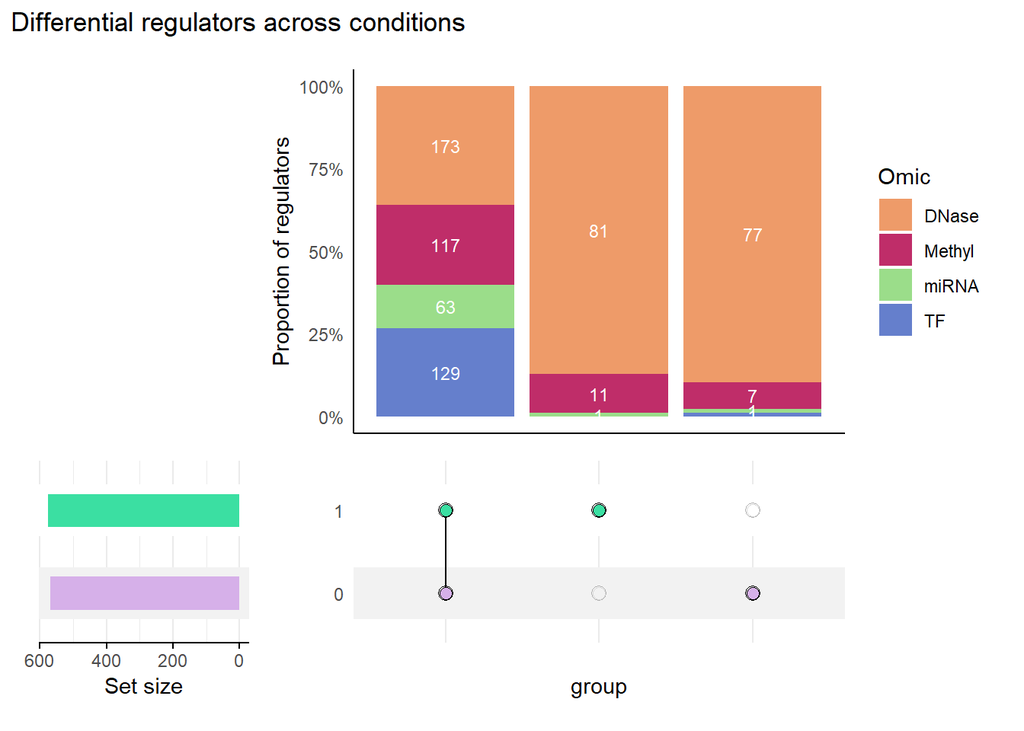

```r
differentialRegPlot(output = PLSJackmodel, outputRegpcond = regpcond_filtered)
```

This plot helps us explore the proportion of significant regulators that are shared in the analyzed conditions and the proportion of condition-specific significant regulators by the regulatory omics.

MORE also provides visualization functions to explore gene-regulator relationships for the pairs identified as significant by MORE.

When no specific regulator is provided, a plot is generated for each gene, displaying all its significant regulators along with the gene’s expression pattern.

To also show how these plots could help us verify the correlated patterns of the regulators detected by MORE, we will create those plots for the MLR with the ElasticNet models’ output.

Since our example gene has many relevant regulators, we will show the regulatory patterns of the Foxo1 TF, which is representative of the mc1_1 group of correlated regulators. In this group, the Gtf2b TF and the mmu-miR-1187 miRNA are positively and negatively correlated regulators with Foxo1, respectively. This results can be observed looking at the expected activation/repression regulatory patterns:

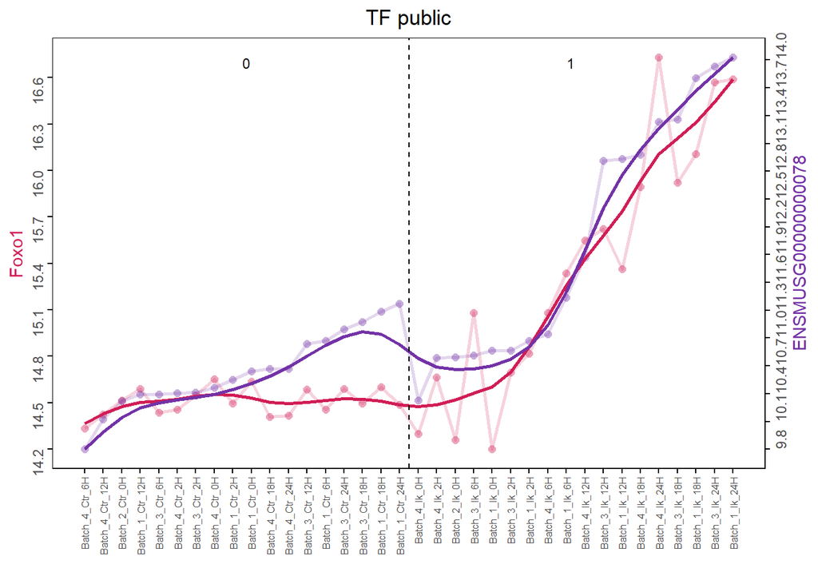

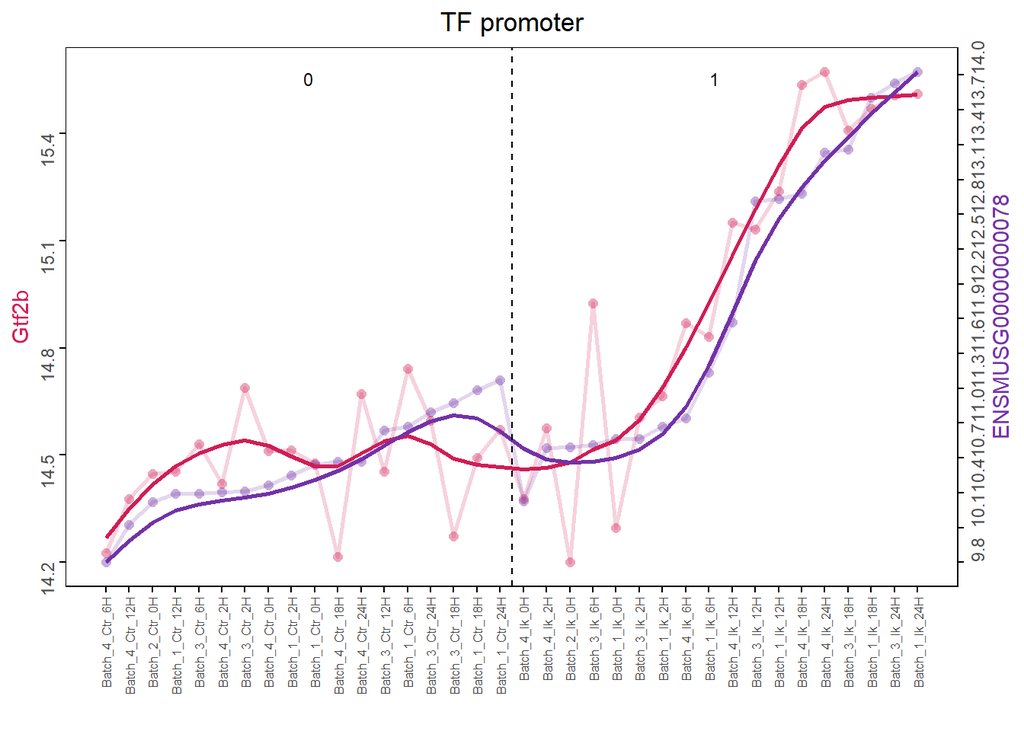

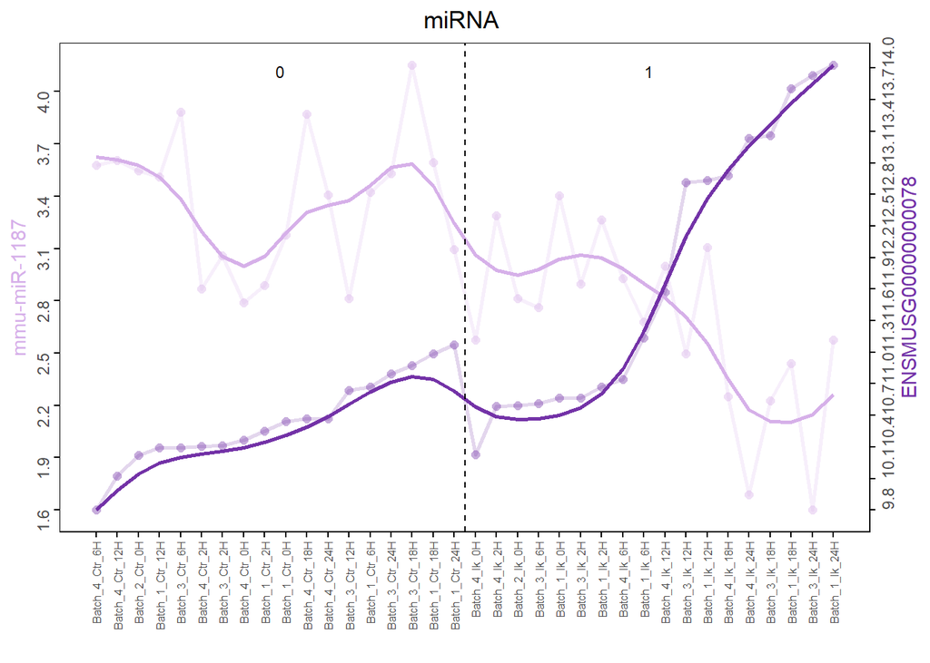

```r
plotMORE(MLRmodel, targetF = "ENSMUSG00000000078", regulator = "Foxo1", order = TRUE, size = 6)

plotMORE(MLRmodel, targetF = "ENSMUSG00000000078", regulator = "Gtf2b", order = TRUE, size = 6)

plotMORE(MLRmodel, targetF = "ENSMUSG00000000078", regulator = "mmu-miR-1187",  order = TRUE, size = 6)
```

When more than 50 observations are considered in the data to be analyzed, identifying patterns becomes difficult. For that reason, to simplify the exploration of the patterns, observations are ordered so that their target feature expression is shown in an ascending way; this is easily done by `order = TRUE`. However, in this specific case, as the dataset contains observations that have been measured also in different data points, exploring those patterns without taking into account this temporality makes no sense. For this reason, in this case, these plots should be re-explored in the following way:

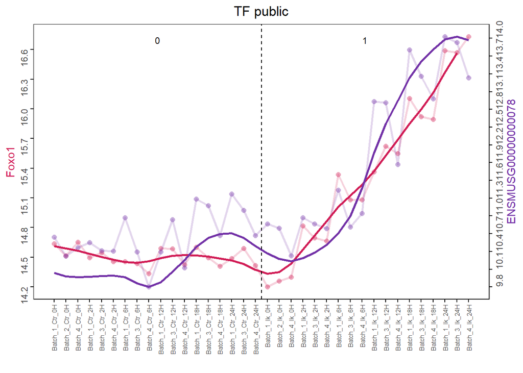

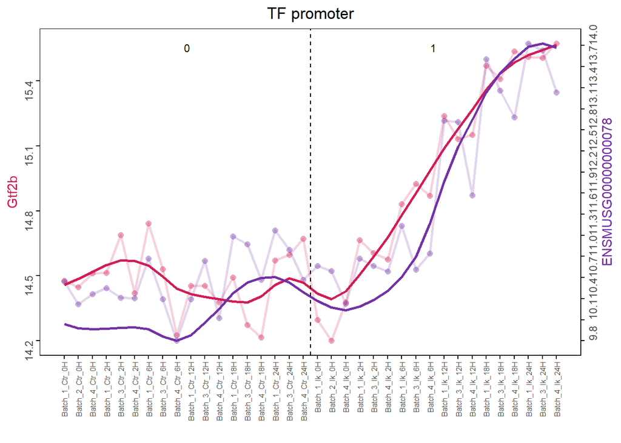

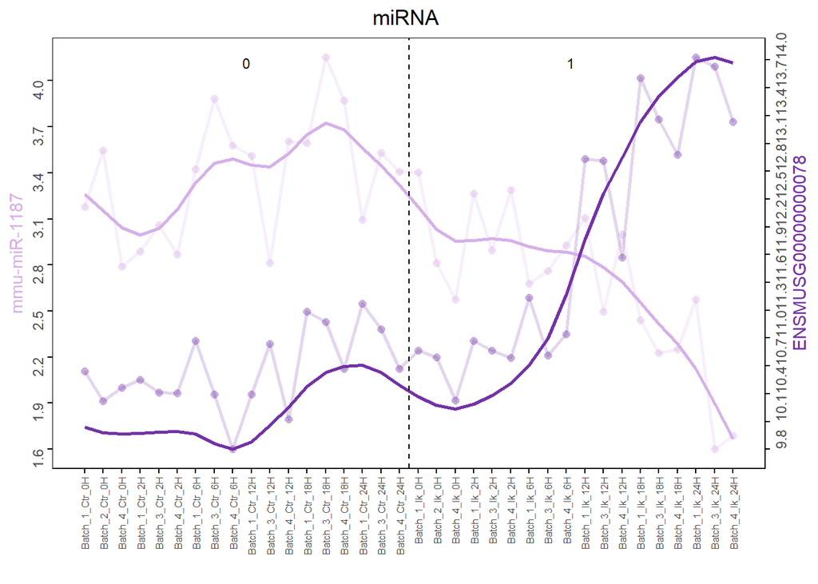

```r
plotMORE(MLRmodel, targetF = "ENSMUSG00000000078", regulator = "Foxo1", order = FALSE, size = 6)
plotMORE(MLRmodel, targetF = "ENSMUSG00000000078", regulator = "Gtf2b", order = FALSE, size = 6)

plotMORE(MLRmodel, targetF = "ENSMUSG00000000078", regulator = "mmu-miR-1187",  order = FALSE, size = 6)
```

Additionally, if a regulator is specified but no gene is provided, MORE will generate plots for all gene–regulator pairs in which that regulator was identified as significant. Let’s do this for miRNA mmu-miR-146a-5p, a miRNA that regulates 4 genes according to the MORE results:

```
## 4 target features are regulated by mmu-miR-146a-5p
```

```
## [1] "ENSMUSG00000026426" "ENSMUSG00000026915" "ENSMUSG00000032383"
## [4] "ENSMUSG00000036890"
```

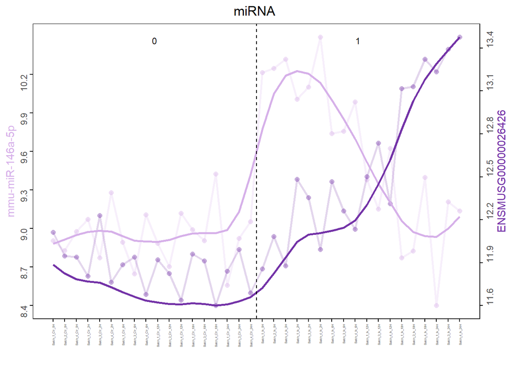

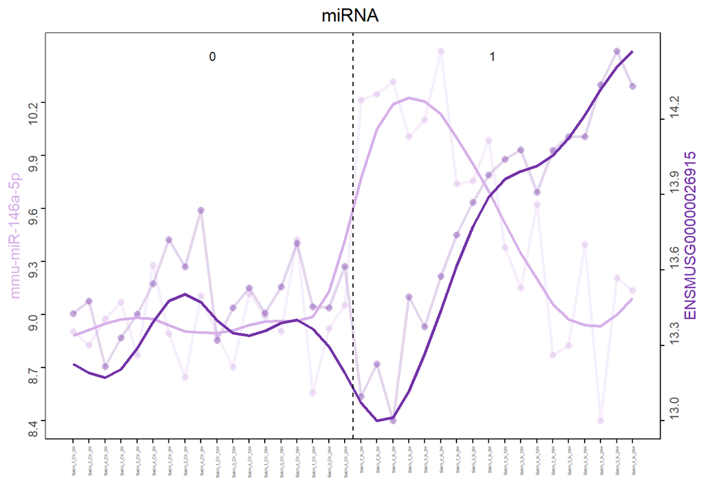

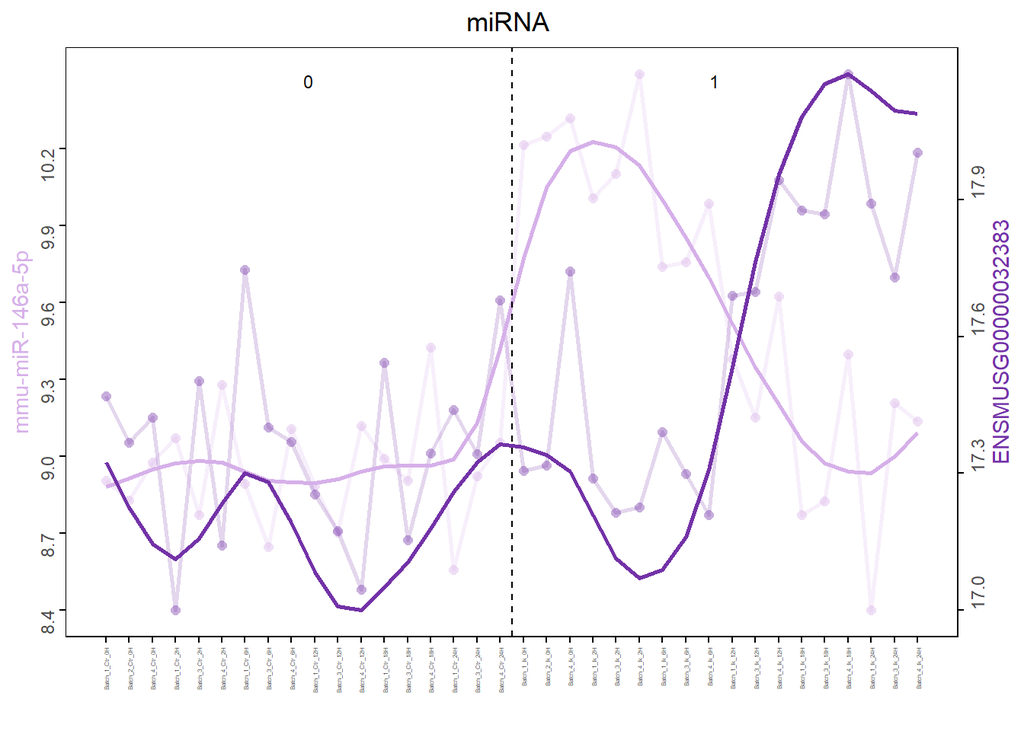

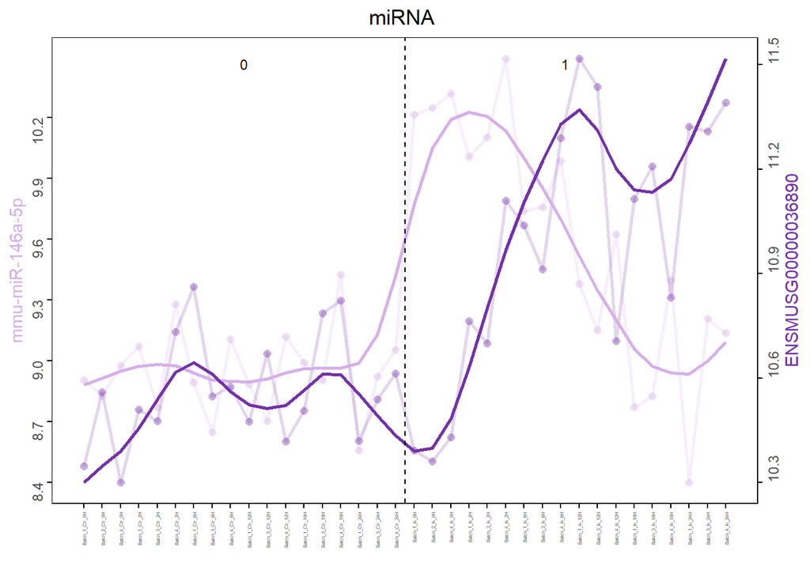

```r
plotMORE(MLRmodel, targetF = NULL, regulator = "mmu-miR-146a-5p", order = FALSE)
```

If the relationship between the gene and the regulator is difficult to discern in those plots, we can simplify them and try to see them in a scatterplot. Re-using the previous example:

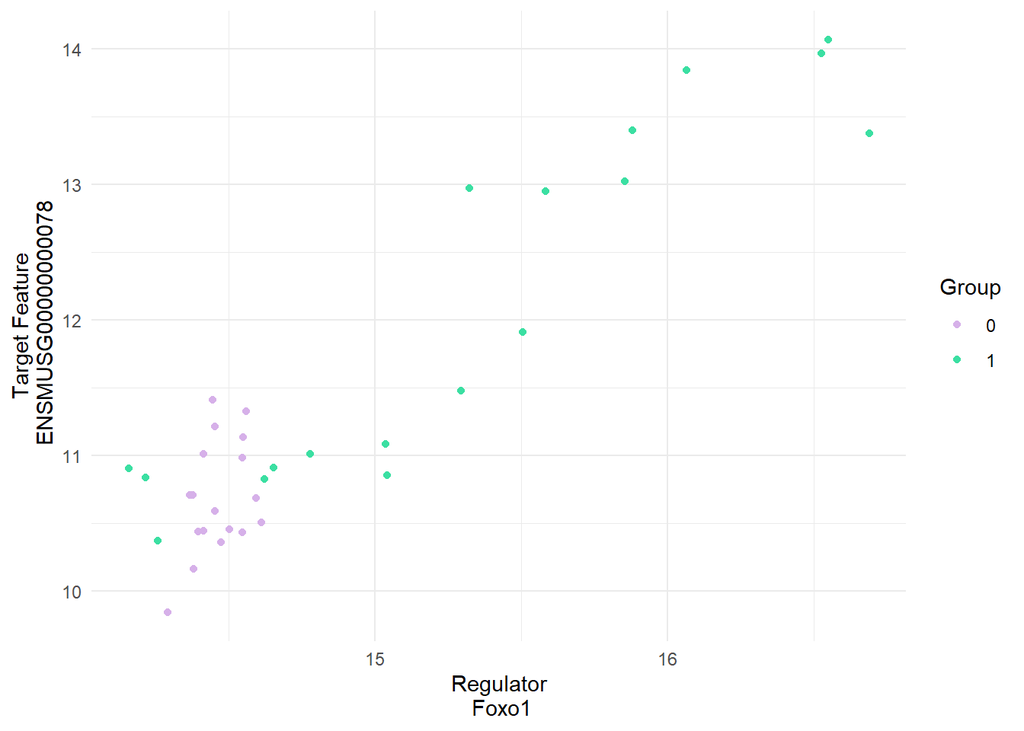

```r
plotMORE(MLRmodel, targetF = "ENSMUSG00000000078", regulator = "Foxo1", simplify =  TRUE)
```

Returning to the results of the PLS model, we can explore the Scores and Weight Plots trying to better understand which regulators co-act, their relation to the gene we are analyzing, and the relation of the conditions with the target feature and the regulators.

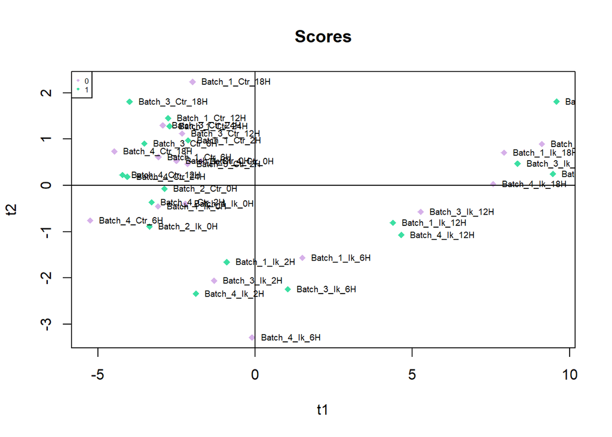

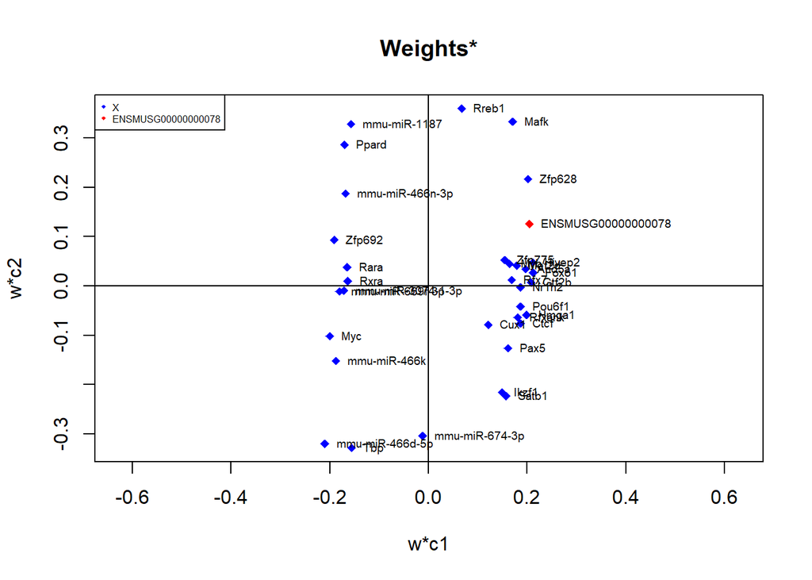

```r
plotScores(PLSJackmodel, targetF = "ENSMUSG00000000078")
plotWeight(PLSJackmodel, targetF = "ENSMUSG00000000078")
```

Looking at the Score plot, first it can be seen how there is not a clear separation between the conditions in the different dimension. Other dimensions should be explored to see if there is any dimension that could explain better the differences across conditions. Looking at the labels, it can not be seen differences according to the different batches. However, looking at the time points it can be seen some aggrupation of the different time points. According to this results, it would be a good idea to take into account this time points in the experimental design when creating the MORE models or correcting the batch effect previous to creating the models.

Additionally, in MORE, we can easily visualize the regulatory networks inferred by MORE using the following code:

[figure not shown]

[figure not shown]

```r
networkMORE(regpcond_filtered, cytoscape = FALSE)
```

Since these networks can be complex to analyze directly in R, MORE includes an extension to export them for interactive exploration in Cytoscape. To enable this, Cytoscape **MUST** be open and operative before executing:

```r
networkMORE(regpcond_filtered, cytoscape = TRUE)
```

This code creates the following networks:

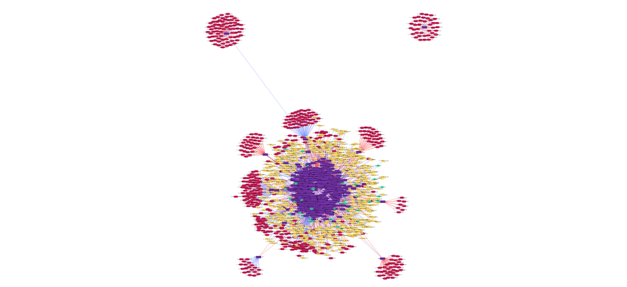

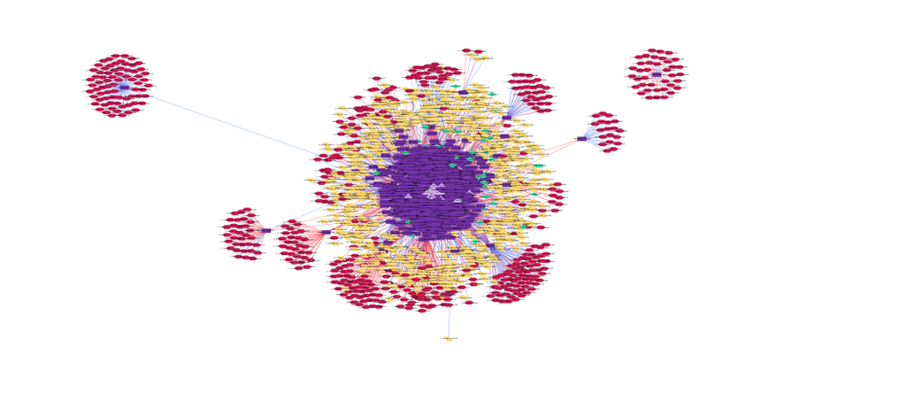

To look only at the different regulations between conditions, we can create differential regulatory networks by:

```r
networkMORE(regpcond_filtered, group1 = '0', group2 = '1', cytoscape = TRUE)
```

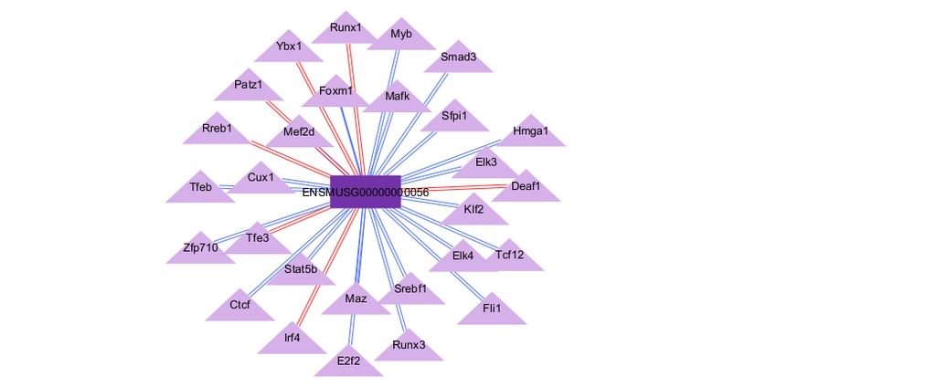

Differential network Control vs Ikaros

# Downstream analysis

The MORE package also includes several functional enrichment functionalities to do a complete downstream analysis.

To use them, we first need an annotation file. In this example, we will download the mouse annotation dataset from Gene Ontology. Please note that we need to format the annotation correctly so that it can be used by MORE. We show an example of the format the annotation should have to use it with MORE:

```r
gene_ids = keys(org.Mm.eg.db, keytype = "ENSEMBL")
annotation = AnnotationDbi::select(org.Mm.eg.db,
                         keys = gene_ids,
                         columns = c('GO','ENSEMBL'),
                         keytype = "ENSEMBL")
GOIDs = unique(annotation$GO)
cl = c('GOID','DEFINITION','TERM')
go_def = AnnotationDbi::select(GO.db, keys=GOIDs, columns=cl, keytype="GOID")
colnames(go_def) = c('GO','GO.definition','GO.term')

annotation = merge(annotation, go_def, by = 'GO', all.x = TRUE)
annotation = annotation[,c(2,1,6,5,3,4)]
annotation = annotation[-which(is.na(annotation$GO)),,drop=FALSE]
head(annotation[,1:3],10)
```

```
##               ENSEMBL         GO                          GO.term
## 1  ENSMUSG00000027424 GO:0000002 mitochondrial genome maintenance
## 2  ENSMUSG00000019699 GO:0000002 mitochondrial genome maintenance
## 3  ENSMUSG00000032449 GO:0000002 mitochondrial genome maintenance
## 4  ENSMUSG00000028982 GO:0000002 mitochondrial genome maintenance
## 5  ENSMUSG00000107283 GO:0000002 mitochondrial genome maintenance
## 6  ENSMUSG00000032449 GO:0000002 mitochondrial genome maintenance
## 7  ENSMUSG00000039264 GO:0000002 mitochondrial genome maintenance
## 8  ENSMUSG00000030879 GO:0000002 mitochondrial genome maintenance
## 9  ENSMUSG00000032449 GO:0000002 mitochondrial genome maintenance
## 10 ENSMUSG00000028982 GO:0000002 mitochondrial genome maintenance
```

## Over Representation Analysis (ORA)

An ORA can be run either for the hub target features or the target features regulated by the global regulators, indicating TRUE or FALSE, respectively, on the `byHubs` parameter. It can be easily done with the following code, but in this case, we will not run it.

```r
regincond_ikaros = RegulationInCondition(regpcond_filtered, cond = '1')

ORA_ikaros = oraMORE(MLRmodel,regincond_ikaros, byHubs = TRUE, annotation = annotation)

ORA_ikaros_globtarget = oraMORE(MLRmodel,regincond_ikaros, byHubs = FALSE, annotation = annotation)
```

The reference gene set for the ORA is formed by the target features (genes in this case) given to the MORE model.

## Gene Set Enrichment Analysis (GSEA)

Users can also perform a Gene Set Enrichment Analysis (GSEA) to compare the number of significant/relevant regulators between the two experimental conditions. As in ORA, the reference gene set is formed by the target features. In this case, the analysis can be run as follows:

```r
regincond_control = RegulationInCondition(regpcond_filtered, cond = '0')
regincond_ikaros = RegulationInCondition(regpcond_filtered, cond = '1')
gsea_out = gseaMORE(regincond_control,regincond_ikaros,  annotation = annotation,p.adjust.method = 'none')
```

```
## using 'fgsea' for GSEA analysis, please cite Korotkevich et al (2019).
```

```
## preparing geneSet collections...
```

```
## GSEA analysis...
```

```
## leading edge analysis...
```

```
## done...
```

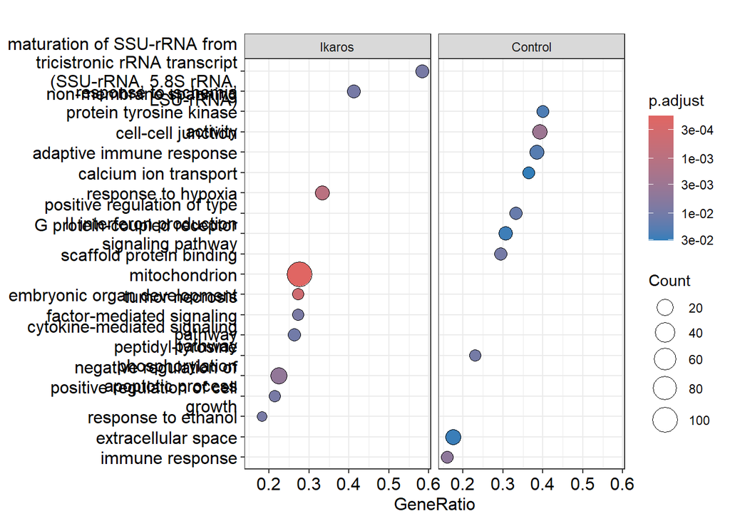

```r
clusterProfiler::dotplot(gsea_out,  split=".sign") +  facet_grid(.~.sign, labeller = as_labeller(c(activated = "Ikaros", suppressed = "Control")))
```

Finally, users may be interested in exploring the regulatory networks associated with a specific pathway—particularly one identified as altered during the GSEA. MORE makes this analysis straightforward.

For example, in the example we were analizing, we could be interested in the *mitochondrion* pathway, so we can run the following to analyze it:

```r
networkMORE(regpcond_filtered, cytoscape = TRUE,annotation = annotation, pathway = 'mitochondrion')
networkMORE(regpcond_filtered, group1 = '0',group2 = '1', cytoscape = TRUE,annotation = annotation, pathway = 'mitochondrion')
```

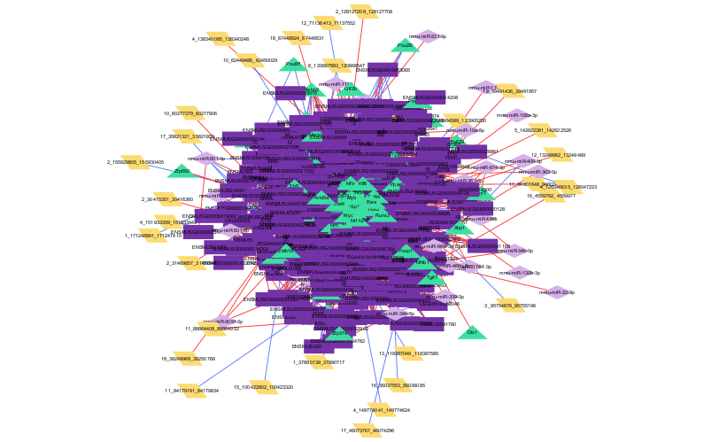

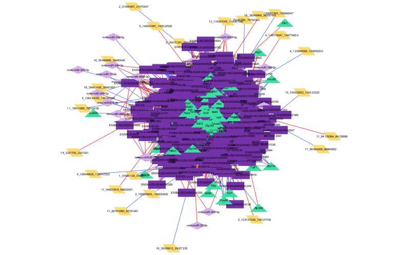

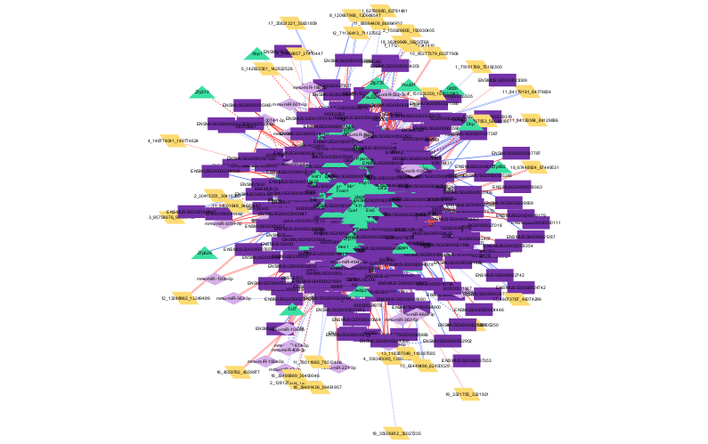